# **LassoCV tuned model**

For this competition, the objective is to use the test dataset to predict whether a rookie NBA player will be playing in the NBA after 5 years. In a never ending quest to find the next Michael Jordan or Kobe Bryant, NBA teams are looking to invest in young players and want to know, with evidence-based analysis, whether their investments will pay off. This vignette will detail the steps undertaken to create a predictive model and the accuracy of the model against the stated aims.

```python
#Initial imports
import pandas as pd
import numpy as np
import seaborn as sb
import matplotlib.pyplot as plt
import os
import sys
sys.path.append(os.path.abspath('..'))
from src.common_lib import DataReader, NBARawData
```

## **Data input and cleansing**

The nominated dataset for training and testing was supplied by the kaggle competition. The training dataset is called train.csv and the test dataset is called test.csv.

```python
#Load dataset using common function DataReader.read_data()
data_reader = DataReader()
# Load Raw Train Data
df_train = data_reader.read_data(NBARawData.TRAIN)
# Load Test Raw Data
df_test = data_reader.read_data(NBARawData.TEST)
```

```python
#For train dataframe, remove redundant column 'Id_old'
df_train.drop('Id_old', axis=1, inplace=True)
df_train.columns = df_train.columns.str.strip()
df_train.describe
```

```
<bound method NDFrame.describe of          Id  GP   MIN   PTS  FGM  FGA   FG%  3P Made  3PA   3P%  ...  FTA  \
0      3799  80  24.3   7.8  3.0  6.4  45.7      0.1  0.3  22.6  ...  2.9
1      3800  75  21.8  10.5  4.2  7.9  55.1     -0.3 -1.0  34.9  ...  3.6
2      3801  85  19.1   4.5  1.9  4.5  42.8      0.4  1.2  34.3  ...  0.6
3      3802  63  19.1   8.2  3.5  6.7  52.5      0.3  0.8  23.7  ...  1.5
4      3803  63  17.8   3.7  1.7  3.4  50.8      0.5  1.4  13.7  ...  0.5
...     ...  ..   ...   ...  ...  ...   ...      ...  ...   ...  ...  ...
7995  11794  32   9.2   1.8  0.7  1.8  40.3     -0.1 -0.2  23.1  ...  0.6
7996  11795  54   6.0   1.8  0.7  1.4  48.7      0.1  0.1   3.1  ...  0.4
7997  11796  85  28.2  10.7  4.0  9.0  45.1      0.2  0.6  23.6  ...  3.9
7998  11797  39   7.7   2.5  1.0  2.3  40.1     -0.3 -0.5  13.3  ...  0.7
7999  11798  49  19.2   4.8  1.7  5.1  32.6      0.7  2.4  41.3  ...  1.3

       FT%  OREB  DREB  REB  AST  STL  BLK  TOV  TARGET_5Yrs
0     72.1   2.2   2.0  3.8  3.2  1.1  0.2  1.6            1
1     67.8   3.6   3.7  6.6  0.7  0.5  0.6  1.4            1
2     75.7   0.6   1.8  2.4  0.8  0.4  0.2  0.6            1
3     66.9   0.8   2.0  3.0  1.8  0.4  0.1  1.9            1
4     54.0   2.4   2.7  4.9  0.4  0.4  0.6  0.7            1
...    ...   ...   ...  ...  ...  ...  ...  ...          ...
7995  65.7   0.3   1.8  1.9  0.5  0.3  0.2  0.4            1
7996  70.1   1.0   1.1  2.0  0.1  0.0  0.3  0.3            1
7997  69.7   1.0   2.1  3.1  3.4  1.2  0.2  1.8            1
7998  74.3   0.4   0.6  0.9  0.2  0.3  0.3  0.5            1
7999  70.1   0.1   1.1  1.2  3.5  0.9 -0.3  1.4            1

[8000 rows x 21 columns]>
```

```python
#For test dataframe, remove redundant column 'Id_old'
df_test.drop('Id_old', axis=1, inplace=True)
df_test.columns = df_test.columns.str.strip()
df_test.describe
```

```
<bound method NDFrame.describe of         Id  GP   MIN   PTS  FGM   FGA   FG%  3P Made  3PA   3P%  FTM  FTA  \
0        0  56   9.1   4.0  1.6   3.7  43.7      0.1  0.3   7.3  0.7  1.2
1        1  43  19.3  10.1  3.7   8.1  46.0      0.6  1.7  35.1  1.8  2.5
2        2  82  33.9  11.3  4.9  10.6  45.6      0.5  1.9  44.8  1.8  2.7
3        3  86  44.7  18.8  6.8  15.9  42.9      0.5  1.8  13.5  4.5  6.3
4        4  58  12.3   4.7  1.6   4.0  40.0      0.5  1.7  38.7  1.1  1.3
...    ...  ..   ...   ...  ...   ...   ...      ...  ...   ...  ...  ...
3794  3794  84  21.2   8.7  3.4   6.7  50.2      0.0  0.0  -4.5  1.7  2.5
3795  3795  49  16.3   6.4  2.9   6.6  44.4     -0.1 -0.4  19.8  1.0  1.9
3796  3796  53   9.9   2.1  0.8   1.8  43.1     -0.4 -0.6   1.9  0.6  1.0
3797  3797  89  38.3  14.5  5.4  11.8  45.2      0.5  1.2  24.7  2.5  2.9
3798  3798  55  12.0   3.0  1.1   2.5  42.3      0.1  0.6  11.7  0.9  1.1

       FT%  OREB  DREB  REB  AST  STL  BLK  TOV
0     63.4   1.2   0.8  1.7  0.4  0.2  0.3  0.8
1     75.3   0.5   0.9  1.5  3.5  0.6  0.0  1.8
2     71.2   1.3   3.3  4.5  2.5  1.3  0.3  2.0
3     70.9   1.5   3.2  5.0  4.1  0.9  0.1  3.6
4     76.9   0.2   0.6  0.9  1.5  0.5 -0.4  0.9
...    ...   ...   ...  ...  ...  ...  ...  ...
3794  68.1   1.9   2.3  3.9  1.5  0.6  0.3  2.0
3795  50.2   1.7   2.8  4.4  0.4  0.4  0.4  0.7
3796  63.9   0.7   1.0  1.7  0.4  0.4  0.2  0.5
3797  89.2   1.5   4.0  5.5  3.7  1.3  0.3  2.4
3798  76.7   0.7   2.0  2.6  0.6  0.3  0.2  1.2

[3799 rows x 20 columns]>
```

## **Feature Correlation and Selection**

When there are two or more correlated features, multicollinearity can occur and this can lead to skewed or misleading results [1]. In order to reduce this from happening, the features have to be examined for colinearity. Pearson correlation was used for this analysis.

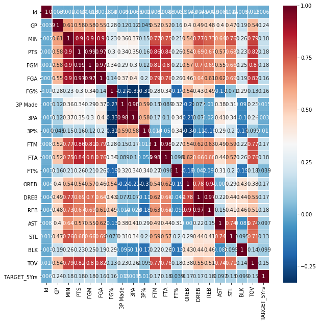

```python
#Use Pearson Correlation to determine feature correlation
pearsoncorr = df_train.corr('pearson')

#Create heatmap of pearson correlation factors
fig, ax = plt.subplots(figsize=(10,10))
sb.heatmap(pearsoncorr,
            xticklabels=pearsoncorr.columns,
            yticklabels=pearsoncorr.columns,
            cmap='RdBu_r',
            annot=True,
            linewidth=0.2)
```

```python
#Drop correlated features w/ score over 0.9 - retain "MINS", "3P MADE", "REB"
cols_drop = ["PTS", "FGM", "FGA", "TOV", "3PA", "FTM", "FTA", "REB"]
df_train.drop(cols_drop, axis=1, inplace=True)
df_test.drop(cols_drop, axis=1, inplace=True)
```

```python
# Split the training dataset using common function data_reader.splitdata
X_train, X_val, y_train, y_val  = data_reader.split_data(df_train)
```

## **Model Selection and Training**

Instead of trial-and-error selection of models, a quick regression model selector was run on common models to see which would yield the lowest mean squared error for the training/validation dataset:

```python
#Classifier imports
from sklearn.metrics import f1_score
from sklearn.metrics import mean_squared_error
from math import sqrt
from sklearn.svm import SVC, LinearSVC, NuSVC
from sklearn import linear_model
from sklearn.linear_model import ElasticNetCV
from sklearn.svm import SVR
from sklearn.cluster import KMeans
from sklearn.linear_model import LassoCV
```

```python
#Select classifiers and display RMSE score:
regressors = [
    linear_model.LassoCV(alphas=None, cv=5, n_jobs=-1),
    linear_model.LinearRegression(),
    ElasticNetCV(alphas=None, copy_X=True, cv=5, eps=0.001, fit_intercept=True,
       l1_ratio=0.5, max_iter=5000, n_alphas=100, n_jobs=None,
       normalize=False, positive=False, precompute='auto', random_state=0,
       selection='cyclic', tol=0.0001, verbose=0),
    SVR(C=1.0, cache_size=200, coef0=0.0, degree=3, epsilon=0.1,
    gamma='auto', kernel='rbf', max_iter=-1, shrinking=True,
    tol=0.001, verbose=False),
    linear_model.Ridge(alpha=.05)
    ]
for regressor in regressors:
    model = regressor
    model.fit(X_train, y_train)
    y_pred_b = model.predict(X_val)
    print(regressor)
    print("mean squared error: %.3f" % sqrt(mean_squared_error(y_val, y_pred_b)))
```

```
LassoCV(alphas=None, copy_X=True, cv=5, eps=0.001, fit_intercept=True,
        max_iter=1000, n_alphas=100, n_jobs=-1, normalize=False, positive=False,
        precompute='auto', random_state=None, selection='cyclic', tol=0.0001,
        verbose=False)
mean squared error: 0.355
LinearRegression(copy_X=True, fit_intercept=True, n_jobs=None, normalize=False)
mean squared error: 0.355
ElasticNetCV(alphas=None, copy_X=True, cv=5, eps=0.001, fit_intercept=True,
             l1_ratio=0.5, max_iter=5000, n_alphas=100, n_jobs=None,
             normalize=False, positive=False, precompute='auto', random_state=0,
             selection='cyclic', tol=0.0001, verbose=0)
mean squared error: 0.355
SVR(C=1.0, cache_size=200, coef0=0.0, degree=3, epsilon=0.1, gamma='auto',
    kernel='rbf', max_iter=-1, shrinking=True, tol=0.001, verbose=False)
mean squared error: 0.375
Ridge(alpha=0.05, copy_X=True, fit_intercept=True, max_iter=None,
      normalize=False, random_state=None, solver='auto', tol=0.001)
mean squared error: 0.355
```

From the above evaluation, it can be seen that all the models except the SVR model returned the same mean squared error (0.355). For this version, the LassoCV model was selected for evaluation. In order to boost accuracy, paramater tuning is employed on the LassoCV to find the optimal alpha value.

```python
#Tune LassoCV
model = LassoCV(alphas=np.arange(0, 1, 0.001), cv=7, n_jobs=-1)
```

```python
model.fit(X_train, y_train);
```

[output not shown]

```python
#Store model in /models
from joblib import dump
dump(model, '../models/LassoCV.joblib')
```

```
['../models/LassoCV.joblib']
```

```python
#Print optimised model parameters
print('alpha: %f' % model.alpha_)
```

```
alpha: 0.000000
```

```python
#Create predictions for train and validation
y_train_preds = model.predict(X_train)
y_val_preds = model.predict(X_val)
#Clip any values > 1, to 1
y_train_preds = np.clip(y_train_preds, a_min=0, a_max=1)
y_val_preds = np.clip(y_val_preds, a_min=0, a_max=1)
```

```python
#Evaluate train predictions
from sklearn.metrics import mean_squared_error as mse
from sklearn.metrics import mean_absolute_error as mae
from sklearn.metrics import confusion_matrix
from sklearn.metrics import accuracy_score

print(mse(y_train, y_train_preds, squared=False))
print(mae(y_train, y_train_preds))
accuracy_score(y_train, y_train_preds.round())
```

```
0.3593551732868761
0.26127733067512326
```

```
0.8328125
```

```python
#Train confusion matrix
confusion_matrix(y_train, y_train_preds.round())
```

```
array([[   4, 1070],
       [   0, 5326]])
```

```python
#Validation set scores
y_val_prediction = model.predict(X_val)
print(mse(y_val, y_val_preds, squared=False))
print(mae(y_val, y_val_preds))
accuracy_score(y_val, y_val_preds.round())
```

```
0.35408590862298644
0.25822627385766544
```

```
0.83875
```

```python
#Validation confusion matrix
confusion_matrix(y_val, y_val_prediction.round())
```

```
array([[   0,  257],
       [   1, 1342]])
```

After training and validation, the LassoCV model achieved an accuracy of 83.2% and 83.9% respectively. It is expected to do well in testing against the final target output.

## **Test output**

The output needs to be formatted to comply with the kaggle competition input requirements. The final steps detail this formatting, as well as the outcome of the model's testing.

```python
#Output predictions
X_test = df_test
y_test_preds = model.predict(X_test)
```

```python
y_test_preds.size
```

```
3799
```

```python
y_test_preds = np.clip(y_test_preds, a_min=0, a_max=1)
```

```python
output = pd.DataFrame({'Id': range(0,3799), 'TARGET_5Yrs': [p for p in y_test_preds]})
```

```python
output.to_csv("../reports/dt_submission_lasso_03.csv", index=False)
```

## **Outcome**

After outputting the predictions into kaggle, the final accuracy was 70.6%. This was not the highest achieved by Jump Shot (Hnin Pwint's logistic regression model scored 71.13%) so some further improvements can be made. The removal of the correlated features improved the accuracy, so that will be retained go forwards. Also, from the model evaluation, the Ridge regression model scored the same mean square error as the other models tested (LassoCV and Elasticnet), so a parameter-tuned Ridge regression model should be evaluated in the future.